[O’Hara on GitHub](https://github.com/oharac)

# Eco-Detectives: chapter 4

Compiled on Sun Jul 1 14:24:16 2018 by ohara

```r
knitr::opts_chunk$set(fig.width = 6, fig.height = 4, fig.path = 'Figs/',
                      echo = TRUE, message = FALSE, warning = FALSE)

source('https://raw.githubusercontent.com/oharac/src/master/R/common.R')
```

$\newcommand{\E}{\mathbb{E}}\newcommand{\Var}{\mathrm{Var}}$

# 1 Chapter 4: Incidental catch in fisheries

## 1.1 Pseudocode 4.1

Here we’ll try a Monte Carlo method to estimate the chance of obtaining meaningful statistical data for incidental catch, for various levels of observer coverage in a fishery. Why use negative binomial? It sounds like it has to do with dispersion… the mean value is not a likely occurrence; variance is significantly higher than the mean (in Poisson, mean and variance are the same value).

In Mangel/Hilborn, the “$m, k$” version for the probability that the bycatch on the $i^{th}$ tow, $C_i$, equals a particular value $c$:

$$\Pr(C_i = c) = p(c) = \frac{\Gamma(k + c)}{\Gamma(k)c!} \left(\frac{k}{k+m}\right)^k \left(\frac{m}{m + k}\right)^c$$
where $m$ is the mean and $k$ is the overdispersion parameter: $\E[C_i] = m; \Var(C_i) = m + \frac{m^2}{k}$.

From page 78, the gamma function is related to factorials, and is calculated from
$$\Gamma(n) = \int_0^{\infty} e^{-t}t^{n-1}dt = \frac{1}{\sum_{k=1}^{\infty} c_k n^k}$$
and for integers,
$$\Gamma(n) = (n-1)!$$

Also in the book, they provide an alternate formulation for negative binomial which matches Casella/Berger: regular binomial counts the number of successes in a fixed number of Bernoulli trials; negative binomial counts the number of Bernoulli trials needed to get a fixed number of successes. C/B use a formulation of

$$\Pr(X = x | r, p) = \binom{x - 1}{r - 1} p^r (1 - p)^{x - r}$$
where $x$ = number of trials at which the $r^{th}$ success occurs, where $r$ is a fixed integer. Poisson is in the negative binomial family as a limiting case, where $r \rightarrow \infty$ and $p\rightarrow 1$.

See the text for how to resolve the two formulations.

### 1.1.1 Specify params

Specify level of observer coverage, $N_{tow}$ per sim, and total number of sims $N_{sim}$, and neg binom params $m, k$. Also specify criterion success $d$ and value of $t_q$.

For $m, k$: From above we know $\E[C_i] = m; \Var(C_i) = m + \frac{m^2}{k} \Longrightarrow k = \frac{m^2}{\Var(C_i) - m}$. Read in the data and calculate these from `mean` and `var`. Because of the construction of table 3, we will calculate mean and variance using the number of tows as weighting factors.
$$\E[N_{birds}] = \frac{\sum_{i}(N_{tows_i} N_{birds_i})} {\sum_i N_{tows_i}}$$
$$\Var(x) = \frac{1}{\sum_i N_{tows_i} - 1} \sum_i \left(N_{tows_i}(N_{birds_i} - \E[N_{birds}])^2\right)$$

```r
inc_catch_df <- readxl::read_excel('~/github/eco_detective/ch_4/data/table_4_3.xlsx',
                                   skip = 2)
### these column names are useless... change 'em to something easy to use:
names(inc_catch_df) <- c('n_caught', 'n_tows')

### mean here is a weighted mean: number of albatrosses weighted by number of tows.
### sample variance is calculated as a weighted sample variance.
inc_catch_sum <- inc_catch_df %>%
  summarize(m = sum(n_caught * n_tows) / sum(n_tows),
            v = sum(n_tows * (n_caught - m)^2) / (sum(n_tows) - 1))

m_data <- inc_catch_sum$m
k_data <- m_data^2 / (inc_catch_sum$v - m_data)
n_tows <- 3000
n_sims <- 200
d_lim  <- .25
t_q    <- 1.645
```

### 1.1.2 Iterate over tows and simulations

- First let’s set up the probability of $n$ birds in by-catch for any given tow (using equation 4.7). From this set up a CDF we can use with a uniform random distribution like we did in chapter 3 Monte Carlo.
  - There may be a negative binomial function built in to R, but let’s do it manually for now.

```r
pr_c <- function(c, m = m_data, k = k_data) { # c <- 0
  ### function to calculate equation 4.7.
  ### NOTE: pr_c() can take a vector of c values and return a vector of probs
  term1 <- gamma(k + c) / (gamma(k) * factorial(c))
  term2 <- (k / (k + m))^k
  term3 <- (m / (m + k))^c

  p <- term1 * term2 * term3
  return(p)
}

birds_per_tow_df <- data.frame(n_birds = 0:40,
                               pr_n    = pr_c(0:40)) %>%
  mutate(cdf_n = cumsum(pr_n),
         cdf_floor = lag(cdf_n, default = 0))
### note the cdf_floor is the probability that count = n - 1.
### So: the range (cdf_floor, cdf_n) brackets the range of probabilities for each n.
### NOTE: the CDF doesn't go all the way to 1, so can run into an error
### if a random draw exceeds the range.
```

- For each simulation:
  - for each tow:
    - pick a random number from uniform dist
    - apply to CDF to pick a number of birds in that tow.

```r
### let's set up a timer so we can compare speeds with a vectorized version later!
ptm <- proc.time()

### first let's set up a matrix, with rows = simulations and columns = number
### of tows, filled with NAs
bycatch_mat <- matrix(data = NA, nrow = n_sims, ncol = n_tows)


for(sim in 1:n_sims) { # sim <- 1

  ### let's add in a print out so we can tell where we are, every 100 sims.
  if(sim %% 100 == 0) { ### i.e. sim is evenly divisible by 100
    message(sim, '... ')  ### without the \n, it will keep writing on the same line
  }

  for(tow in 1:n_tows) { # tow <- 1

    ### draw the uniform random:
    draw <- runif(n = 1, min = 0, max = 1)
    ### NOTE: this is pretty clunky...
    ### compare to the CDF column; we want the observation where our draw
    ### falls within the CDF range.   So if the probability of
    ### say 3 birds or fewer birds is 0.9762582, and the prob of 4 or fewer
    ### birds is 0.9831761, and we draw .980, then we want to match 4 birds.
    ### So chopping up the logic:
    in_cdf  <- which(draw > birds_per_tow_df$cdf_floor & draw < birds_per_tow_df$cdf_n)
      ### what is the index of the row that falls within the CDF?
    n_birds <- birds_per_tow_df$n_birds[in_cdf]

    if(length(n_birds) == 0) {
      ### error check: in case our draw exceeded the ranges in the dataframe...
      n_birds = max(birds_per_tow_df$n_birds + 1)
    }

    # cat(sprintf('draw = %f, n_birds = %s\n', draw, n_birds))
    bycatch_mat[sim, tow] <- n_birds
  }
}

t_elapsed <- proc.time() - ptm
cat('time: ', t_elapsed[3], 'seconds')
```

```
## time:  10.849 seconds
```

```r
### let's set up a function to return a number of birds for a given draw
in_cdf_fxn <- function(x, df) {
  y <- which(x > df$cdf_floor & x < df$cdf_n)
}

random_birds <- function(draw, df = birds_per_tow_df) {
  ### If draw is outside the bounds
  ### for the cdf values in the dataframe, just set it to the last value
  ### (i.e. if 40 is the max n, then anything higher than 40 gets set to 40)

  if(length(draw) > 1) {
    ### If draw is longer than 1 element, use sapply so draw can be a vector.
    in_cdf  <- sapply(draw, FUN = function(x) {
      y <- in_cdf_fxn(x, df)
      if (length(y) == 0) y <- nrow(df)
      return(y)
    })
  } else {
      in_cdf <- in_cdf_fxn(draw, df)
      if (length(in_cdf) == 0) {
        in_cdf <- nrow(df)
      }
  }

  n_birds <- df$n_birds[in_cdf]
    ### this can take a vector and return a vector; error checking has to
    ### be done first.

  return(n_birds)
}
```

```r
### let's set up a timer so we can compare speeds with a vectorized version later!
ptm <- proc.time()

### first let's set up a matrix, with rows = simulations and columns = number
### of tows, filled with NAs
bycatch_mat <- matrix(data = NA, nrow = n_sims, ncol = n_tows)

for(sim in 1:n_sims) { # sim <- 1

  ### let's add in a print out so we can tell where we are, every 100 sims.
  if(sim %% 100 == 0) { ### i.e. sim is evenly divisible by 100
    message(sim, '... ')  ### without the \n, it will keep writing on the same line
  }

  for(tow in 1:n_tows) { # tow <- 1

    ### draw the uniform random:
    draw <- runif(n = 1, min = 0, max = 1)

    bycatch_mat[sim, tow] <- random_birds(draw)
  }
}

t_elapsed <- proc.time() - ptm
cat('time: ', t_elapsed[3], 'seconds')

### comparable to hard-coded version since it only uses the sapply in the function if draw is a vector.
```

[output not shown]

```r
### let's set up a timer so we can compare speeds with a vectorized version later!
ptm <- proc.time()

### Set up a dataframe, with rows and sims
bycatch_df <- data.frame(sim = rep(1:n_sims, each = n_tows),
                         tow = rep(1:n_tows, times = n_sims)) %>%
  ### draw the uniform random and calculate number of birds
  mutate(draw = runif(n = n(), min = 0, max = 1)) %>%
  mutate(n_birds = random_birds(draw))

t_elapsed <- proc.time() - ptm
cat('time: ', t_elapsed[3], 'seconds')
```

```
## time:  9.78 seconds
```

Faster with vectorization.

### 1.1.3 Compute mean and variance for each simulation

Use rowSums() and colSums() to work with matrices. Since each row is a simulation, use rowSums to calc the sum of all observed bird bycatch in each tow, for mean.

If we use `rowSums(x - y)` where `x` is the matrix and `y` is the row means, we should get each element in the row minus the row mean. This doesn’t work so well for `colSums()` since the vector of means gets applied vertically, not horizontally. I think this can be changed in R but whatever…

```r
system.time({
  sim_means <- 1/n_tows * rowSums(bycatch_mat)

  sim_vars  <- 1/(n_tows - 1) * rowSums((bycatch_mat - sim_means)^2)
})
```

```
##    user  system elapsed
##   0.004   0.000   0.005
```

```r
system.time({
sim_means_df <- bycatch_df %>%
  group_by(sim) %>%
  summarize(mean = 1/n_tows * sum(n_birds),
            var  = 1/(n_tows - 1) * sum((n_birds - mean)^2))
})
```

```
##    user  system elapsed
##   0.032   0.000   0.029
```

rowSums() is really fast!

### 1.1.4 Compute successes

```r
success_df <- sim_means_df %>%
  mutate(range = 2 * sqrt(var / n_tows) * t_q,
         success = range < d_lim * mean)

sum(success_df$success)
```

```
## [1] 16
```

## 1.2 Combine into one big loop to try multiple values of n_tows

```r
### set up a vector of n_tows values:

n_tows_vec <- seq(250, 5000, 250)
success_vec <- rep(NA, length(n_tows_vec))

for(i in seq_along(n_tows_vec)) {

  n_tows <- n_tows_vec[i]
  ### Set up a dataframe, with rows and sims
  bycatch_df <- data.frame(sim = rep(1:n_sims, each = n_tows),
                           tow = rep(1:n_tows, times = n_sims)) %>%
    ### draw the uniform random and calculate number of birds
    mutate(draw = runif(n = n(), min = 0, max = 1)) %>%
    mutate(n_birds = random_birds(draw))

  sim_means_df <- bycatch_df %>%
    group_by(sim) %>%
    summarize(mean = 1/n_tows * sum(n_birds),
              var  = 1/(n_tows - 1) * sum((n_birds - mean)^2))

  success_df <- sim_means_df %>%
    mutate(range = 2 * sqrt(var / n_tows) * t_q,
           success = range < d_lim * mean)

  success_vec[i] <- sum(success_df$success) / n_sims
}
```

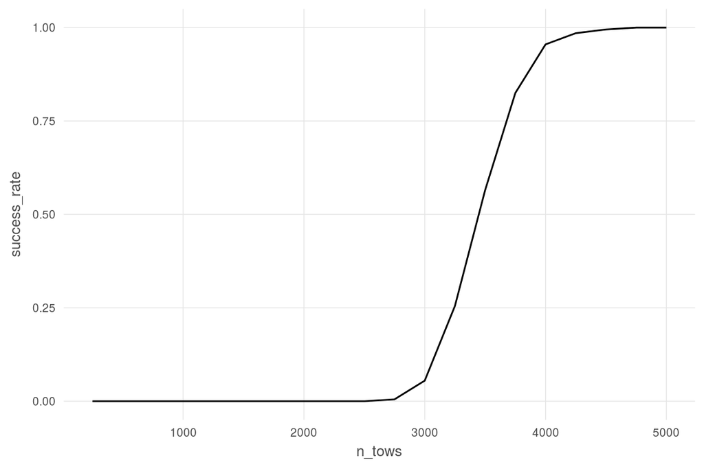

```r
success_df <- data.frame('n_tows'       = n_tows_vec,
                         'success_rate' = success_vec)

ggplot(success_df, aes(x = n_tows, y = success_rate)) +
  ggtheme_plot() +
  geom_line()
```